# MD_3_homework_CR

Christoph Rosa

2022-09-09

# Set-up

Installing packages and clearing environmnent.

```r
library(tidyverse)
rm(list = ls())
```

Downloading our main dataset.

```r
mariokart <- read_csv("../Data/world_records.csv")
glimpse(mariokart)
```

```
## Rows: 2,334
## Columns: 9
## $ track           <chr> "Luigi Raceway", "Luigi Raceway", "Luigi Raceway", "Lu…
## $ type            <chr> "Three Lap", "Three Lap", "Three Lap", "Three Lap", "T…
## $ shortcut        <chr> "No", "No", "No", "No", "No", "No", "No", "No", "No", …
## $ player          <chr> "Salam", "Booth", "Salam", "Salam", "Gregg G", "Rocky …
## $ system_played   <chr> "NTSC", "NTSC", "NTSC", "NTSC", "NTSC", "NTSC", "NTSC"…
## $ date            <date> 1997-02-15, 1997-02-16, 1997-02-16, 1997-02-28, 1997-…
## $ time_period     <chr> "2M 12.99S", "2M 9.99S", "2M 8.99S", "2M 6.99S", "2M 4…
## $ time            <dbl> 132.99, 129.99, 128.99, 126.99, 124.51, 122.89, 122.87…
## $ record_duration <dbl> 1, 0, 12, 7, 54, 0, 0, 27, 0, 64, 3, 0, 90, 132, 1, 74…
```

# Question 1

Filtering out any records that wasn’t over three laps.

```r
threelaps <- mariokart %>% filter(type == "Three Lap")
```

Filtering out any childhood trauma:

```r
norainbow <- threelaps %>% filter(track != "Rainbow Road")
```

And now the opposite, only Rainbow Road records:

```r
rainbow <- threelaps %>% filter(track == "Rainbow Road")
```

# Question 2

```r
rainbow %>% summarize(mean = mean(time), sd = sd(time))
```

```
## # A tibble: 1 × 2
##    mean    sd
##   <dbl> <dbl>
## 1  276.  91.8
```

```r
norainbow %>% summarize(mean = mean(time), sd = sd(time))
```

```
## # A tibble: 1 × 2
##    mean    sd
##   <dbl> <dbl>
## 1  114.  53.0
```

As expected, the average world records on Rainbow Road are more than twice as long as the average records on all other tracks. Their standard deviation is also much higher, so apparently their was more room for improvement since the first records were set.

# Question 3

```r
threelaps %>% group_by(track) %>%
  summarize(records = n()) %>%
  arrange(records)
```

```
## # A tibble: 16 × 2
##    track                 records
##    <chr>                   <int>
##  1 Bowser's Castle            40
##  2 Moo Moo Farm               44
##  3 Banshee Boardwalk          55
##  4 Koopa Troopa Beach         56
##  5 Wario Stadium              71
##  6 Kalimari Desert            73
##  7 Sherbet Land               73
##  8 Yoshi Valley               74
##  9 Royal Raceway              77
## 10 Luigi Raceway              81
## 11 Mario Raceway              82
## 12 Choco Mountain             84
## 13 D.K.'s Jungle Parkway      86
## 14 Frappe Snowland            92
## 15 Rainbow Road               99
## 16 Toad's Turnpike           124
```

The track for which the most records were set is Toad’s Turnpike, with a total of 124.

# Question 4

```r
threelaps %>% group_by(track, player) %>%
  summarize(driverrecords = n()) %>%
  arrange(desc(driverrecords))
```

```
## # A tibble: 306 × 3
## # Groups:   track [16]
##    track                 player   driverrecords
##    <chr>                 <chr>            <int>
##  1 Choco Mountain        Penev               26
##  2 D.K.'s Jungle Parkway Lacey               24
##  3 Rainbow Road          abney317            21
##  4 Toad's Turnpike       MR                  20
##  5 Frappe Snowland       MR                  18
##  6 Toad's Turnpike       Penev               18
##  7 Kalimari Desert       abney317            16
##  8 Sherbet Land          MR                  16
##  9 Banshee Boardwalk     MR                  15
## 10 Choco Mountain        abney317            15
## # … with 296 more rows
```

With 26 distinct records on the track Choco Mountain, Penev is the driver with the most records on any one track.

# Question 5

```r
threelaps %>% group_by(track) %>%
  summarize(mean = mean(time)) %>%
  arrange(desc(mean))
```

```
## # A tibble: 16 × 2
##    track                  mean
##    <chr>                 <dbl>
##  1 Rainbow Road          276.
##  2 Wario Stadium         214.
##  3 Royal Raceway         158.
##  4 Bowser's Castle       134.
##  5 Kalimari Desert       126.
##  6 Banshee Boardwalk     126.
##  7 Toad's Turnpike       122.
##  8 Sherbet Land          116.
##  9 Luigi Raceway         104.
## 10 D.K.'s Jungle Parkway 101.
## 11 Koopa Troopa Beach     96.6
## 12 Choco Mountain         95.2
## 13 Moo Moo Farm           88.4
## 14 Yoshi Valley           82.7
## 15 Mario Raceway          79.1
## 16 Frappe Snowland        77.1
```

As we would expect, Rainbow Road is the track with the highest average time, followed by Wario Stadium with quite some distance.

```r
threelaps %>%
  group_by(player) %>%
  arrange(time) %>%
  slice(1) %>%
  head()
```

```
## # A tibble: 6 × 9
## # Groups:   player [6]
##   track           type   short…¹ player syste…² date       time_…³  time recor…⁴
##   <chr>           <chr>  <chr>   <chr>  <chr>   <date>     <chr>   <dbl>   <dbl>
## 1 Choco Mountain  Three… Yes     ABE    NTSC    1997-06-01 1M 39.…  99.8      23
## 2 Choco Mountain  Three… Yes     abney… NTSC    2021-02-03 17.29S   17.3      23
## 3 Yoshi Valley    Three… Yes     Alex G PAL     2010-11-27 33.39S   33.4    3659
## 4 Frappe Snowland Three… Yes     Allen… NTSC    1997-10-31 28.22S   28.2       0
## 5 Wario Stadium   Three… Yes     Ben M  PAL     2002-08-22 15.48S   15.5    1370
## 6 Frappe Snowland Three… Yes     Booth  NTSC    1998-09-18 27.11S   27.1      74
## # … with abbreviated variable names ¹shortcut, ²system_played, ³time_period,
## #   ⁴record_duration
```

Let’s get each track’s best time:

```r
threelaps %>%
  group_by(track) %>%
  arrange(time) %>%
  slice(1) %>%
  select(track, time)
```

```
## # A tibble: 16 × 2
## # Groups:   track [16]
##    track                  time
##    <chr>                 <dbl>
##  1 Banshee Boardwalk     124.
##  2 Bowser's Castle       132
##  3 Choco Mountain         17.3
##  4 D.K.'s Jungle Parkway  21.4
##  5 Frappe Snowland        23.6
##  6 Kalimari Desert       122.
##  7 Koopa Troopa Beach     95.2
##  8 Luigi Raceway          25.3
##  9 Mario Raceway          58.5
## 10 Moo Moo Farm           85.9
## 11 Rainbow Road           50.4
## 12 Royal Raceway         119.
## 13 Sherbet Land           91.6
## 14 Toad's Turnpike        30.3
## 15 Wario Stadium          14.6
## 16 Yoshi Valley           33.4
```

# Question 6

Let’s see which records held for more than 100 days and create a binary variable for that:

```r
longrecords <- threelaps %>%
  mutate(long = if_else(record_duration > 100, 1, 0))
```

Let’s find out which player sets the most durable records:

```r
longrecords %>% filter(long == 1) %>%
  group_by(player) %>%
  summarize(records = n()) %>%
  arrange(desc(records))
```

```
## # A tibble: 42 × 2
##    player   records
##    <chr>      <int>
##  1 MR            81
##  2 MJ            50
##  3 Penev         27
##  4 abney317      26
##  5 VAJ           26
##  6 Zwartjes      24
##  7 Lacey         23
##  8 Dan           21
##  9 Karlo         18
## 10 Booth         17
## # … with 32 more rows
```

The driver MR had the most records that last for more than a hundred days, 81 in total.

# Question 7

Downloading our second dataset, we’ll only keep the variable “nationality” of each player:

```r
drivers <- read_csv("../Data/drivers.csv") %>%
  select(player, nation) %>%
  distinct()
glimpse(drivers)
```

```
## Rows: 90
## Columns: 2
## $ player <chr> "Penev", "MR", "abney317", "Dan", "MJ", "Booth", "VAJ", "Zwartj…
## $ nation <chr> "Australia", "Germany", "USA", "USA", "Netherlands", "USA", "Ne…
```

After left-joining the nationality info to our records data, we can compare how each country is doing by creating a barplot:

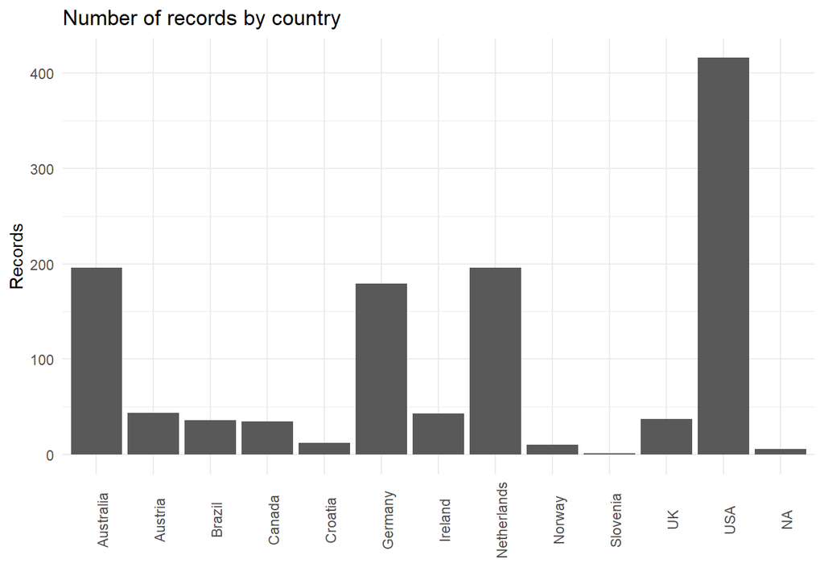

```r
data <- left_join(threelaps, drivers, by = "player")

ggplot(data,
       aes(nation)) +
  geom_bar() +
  theme_minimal() +
  theme(axis.text.x = element_text(angle = 90)) +
  labs(title = "Number of records by country",
       x = "",
       y = "Records")
```